# CA0-AI-810199554

```python
import pandas as pd
import numpy as np
import matplotlib.pyplot as plt
import scipy.stats as stats
my_data_frame = pd.read_csv("train.csv")
my_data_frame
```

|  | PassengerId | Survived | Pclass | Name | Sex | Age | SibSp | Parch | Ticket | Fare | Cabin | Embarked |
| --- | --- | --- | --- | --- | --- | --- | --- | --- | --- | --- | --- | --- |
| 0 | 1 | 0 | 3 | Braund, Mr. Owen Harris | male | 22.0 | 1 | 0 | A/5 21171 | 7.2500 | NaN | S |
| 1 | 2 | 1 | 1 | Cumings, Mrs. John Bradley (Florence Briggs Th... | female | 38.0 | 1 | 0 | PC 17599 | 71.2833 | C85 | C |
| 2 | 3 | 1 | 3 | Heikkinen, Miss. Laina | female | 26.0 | 0 | 0 | STON/O2. 3101282 | 7.9250 | NaN | S |
| 3 | 4 | 1 | 1 | Futrelle, Mrs. Jacques Heath (Lily May Peel) | female | 35.0 | 1 | 0 | 113803 | 53.1000 | C123 | S |
| 4 | 5 | 0 | 3 | Allen, Mr. William Henry | male | 35.0 | 0 | 0 | 373450 | 8.0500 | NaN | S |
| ... | ... | ... | ... | ... | ... | ... | ... | ... | ... | ... | ... | ... |
| 886 | 887 | 0 | 2 | Montvila, Rev. Juozas | male | 27.0 | 0 | 0 | 211536 | 13.0000 | NaN | S |
| 887 | 888 | 1 | 1 | Graham, Miss. Margaret Edith | female | 19.0 | 0 | 0 | 112053 | 30.0000 | B42 | S |
| 888 | 889 | 0 | 3 | Johnston, Miss. Catherine Helen "Carrie" | female | NaN | 1 | 2 | W./C. 6607 | 23.4500 | NaN | S |
| 889 | 890 | 1 | 1 | Behr, Mr. Karl Howell | male | 26.0 | 0 | 0 | 111369 | 30.0000 | C148 | C |
| 890 | 891 | 0 | 3 | Dooley, Mr. Patrick | male | 32.0 | 0 | 0 | 370376 | 7.7500 | NaN | Q |

891 rows × 12 columns

```python
my_data_frame.describe()
```

|  | PassengerId | Survived | Pclass | Age | SibSp | Parch | Fare |
| --- | --- | --- | --- | --- | --- | --- | --- |
| count | 891.000000 | 891.000000 | 891.000000 | 714.000000 | 891.000000 | 891.000000 | 891.000000 |
| mean | 446.000000 | 0.383838 | 2.308642 | 29.699118 | 0.523008 | 0.381594 | 32.204208 |
| std | 257.353842 | 0.486592 | 0.836071 | 14.526497 | 1.102743 | 0.806057 | 49.693429 |
| min | 1.000000 | 0.000000 | 1.000000 | 0.420000 | 0.000000 | 0.000000 | 0.000000 |
| 25% | 223.500000 | 0.000000 | 2.000000 | 20.125000 | 0.000000 | 0.000000 | 7.910400 |
| 50% | 446.000000 | 0.000000 | 3.000000 | 28.000000 | 0.000000 | 0.000000 | 14.454200 |
| 75% | 668.500000 | 1.000000 | 3.000000 | 38.000000 | 1.000000 | 0.000000 | 31.000000 |
| max | 891.000000 | 1.000000 | 3.000000 | 80.000000 | 8.000000 | 6.000000 | 512.329200 |

```python
my_data_frame.head()
```

|  | PassengerId | Survived | Pclass | Name | Sex | Age | SibSp | Parch | Ticket | Fare | Cabin | Embarked |
| --- | --- | --- | --- | --- | --- | --- | --- | --- | --- | --- | --- | --- |
| 0 | 1 | 0 | 3 | Braund, Mr. Owen Harris | male | 22.0 | 1 | 0 | A/5 21171 | 7.2500 | NaN | S |
| 1 | 2 | 1 | 1 | Cumings, Mrs. John Bradley (Florence Briggs Th... | female | 38.0 | 1 | 0 | PC 17599 | 71.2833 | C85 | C |
| 2 | 3 | 1 | 3 | Heikkinen, Miss. Laina | female | 26.0 | 0 | 0 | STON/O2. 3101282 | 7.9250 | NaN | S |
| 3 | 4 | 1 | 1 | Futrelle, Mrs. Jacques Heath (Lily May Peel) | female | 35.0 | 1 | 0 | 113803 | 53.1000 | C123 | S |
| 4 | 5 | 0 | 3 | Allen, Mr. William Henry | male | 35.0 | 0 | 0 | 373450 | 8.0500 | NaN | S |

متد هد باعث پرینت شدن 5 سطر ابتدایی از دیتای فریم ما میشود که البته با دادن آرگومان عددی مناسب به آن میتوان تعداد سطرهای که چاپ میشنود را افزایش و یا کاهش داد

```python
my_data_frame.tail()
```

|  | PassengerId | Survived | Pclass | Name | Sex | Age | SibSp | Parch | Ticket | Fare | Cabin | Embarked |
| --- | --- | --- | --- | --- | --- | --- | --- | --- | --- | --- | --- | --- |
| 886 | 887 | 0 | 2 | Montvila, Rev. Juozas | male | 27.0 | 0 | 0 | 211536 | 13.00 | NaN | S |
| 887 | 888 | 1 | 1 | Graham, Miss. Margaret Edith | female | 19.0 | 0 | 0 | 112053 | 30.00 | B42 | S |
| 888 | 889 | 0 | 3 | Johnston, Miss. Catherine Helen "Carrie" | female | NaN | 1 | 2 | W./C. 6607 | 23.45 | NaN | S |
| 889 | 890 | 1 | 1 | Behr, Mr. Karl Howell | male | 26.0 | 0 | 0 | 111369 | 30.00 | C148 | C |
| 890 | 891 | 0 | 3 | Dooley, Mr. Patrick | male | 32.0 | 0 | 0 | 370376 | 7.75 | NaN | Q |

متد تیل باعث پرینت شدن 5 سطر انتهایی دیتا فریم ما میشود که البته با دادن آرگومان عددی مناسب به آن میتوان تعداد سطرهای که پرینت میشنود را افزایش و یا کاهش داد

```python
my_data_frame.info()
```

```
<class 'pandas.core.frame.DataFrame'>
RangeIndex: 891 entries, 0 to 890
Data columns (total 12 columns):
 #   Column       Non-Null Count  Dtype
---  ------       --------------  -----
 0   PassengerId  891 non-null    int64
 1   Survived     891 non-null    int64
 2   Pclass       891 non-null    int64
 3   Name         891 non-null    object
 4   Sex          891 non-null    object
 5   Age          714 non-null    float64
 6   SibSp        891 non-null    int64
 7   Parch        891 non-null    int64
 8   Ticket       891 non-null    object
 9   Fare         891 non-null    float64
 10  Cabin        204 non-null    object
 11  Embarked     889 non-null    object
dtypes: float64(2), int64(5), object(5)
memory usage: 83.7+ KB
```

در متد اینفو ابتدا رنج ایندکس و تعداد ستون های دیتای ما مشخص شده است  
و در ادامه تمامی ستون های دیتا فریم ما و نوع دیتای آن ها و تعداد دیتاهایی که در هر ستون نال نیستند و در نهایت تعداد ستون ها با دیتاتایپ های مختلف پرینت شده است

```python
my_data_frame['Sex'].replace(['male', 'female'],[0, 1], inplace=True)
```

```python
my_data_frame
```

|  | PassengerId | Survived | Pclass | Name | Sex | Age | SibSp | Parch | Ticket | Fare | Cabin | Embarked |
| --- | --- | --- | --- | --- | --- | --- | --- | --- | --- | --- | --- | --- |
| 0 | 1 | 0 | 3 | Braund, Mr. Owen Harris | 0 | 22.0 | 1 | 0 | A/5 21171 | 7.2500 | NaN | S |
| 1 | 2 | 1 | 1 | Cumings, Mrs. John Bradley (Florence Briggs Th... | 1 | 38.0 | 1 | 0 | PC 17599 | 71.2833 | C85 | C |
| 2 | 3 | 1 | 3 | Heikkinen, Miss. Laina | 1 | 26.0 | 0 | 0 | STON/O2. 3101282 | 7.9250 | NaN | S |
| 3 | 4 | 1 | 1 | Futrelle, Mrs. Jacques Heath (Lily May Peel) | 1 | 35.0 | 1 | 0 | 113803 | 53.1000 | C123 | S |
| 4 | 5 | 0 | 3 | Allen, Mr. William Henry | 0 | 35.0 | 0 | 0 | 373450 | 8.0500 | NaN | S |
| ... | ... | ... | ... | ... | ... | ... | ... | ... | ... | ... | ... | ... |
| 886 | 887 | 0 | 2 | Montvila, Rev. Juozas | 0 | 27.0 | 0 | 0 | 211536 | 13.0000 | NaN | S |
| 887 | 888 | 1 | 1 | Graham, Miss. Margaret Edith | 1 | 19.0 | 0 | 0 | 112053 | 30.0000 | B42 | S |
| 888 | 889 | 0 | 3 | Johnston, Miss. Catherine Helen "Carrie" | 1 | NaN | 1 | 2 | W./C. 6607 | 23.4500 | NaN | S |
| 889 | 890 | 1 | 1 | Behr, Mr. Karl Howell | 0 | 26.0 | 0 | 0 | 111369 | 30.0000 | C148 | C |
| 890 | 891 | 0 | 3 | Dooley, Mr. Patrick | 0 | 32.0 | 0 | 0 | 370376 | 7.7500 | NaN | Q |

891 rows × 12 columns

```python
my_data_frame.isna().sum()
```

```
PassengerId      0
Survived         0
Pclass           0
Name             0
Sex              0
Age            177
SibSp            0
Parch            0
Ticket           0
Fare             0
Cabin          687
Embarked         2
dtype: int64
```

```python
my_data_frame['Age'] = my_data_frame['Age'].fillna(my_data_frame['Age'].mean())
```

مزایا:این اقدام بسیار بهتری نسبت به پر کردن مقادیر نال با مقادیری مانند صفر و یا -999 است  
معایب:با این اقدام درست است که میانگین تغییری نمیکند اما در نحوه توزیع داده ها تاثیر دارد و بیشترین تاثیر در وسط این توزیع میباشد و میزان داده ها میانگین افزایش پیدا میکند

```python
my_data_frame
```

|  | PassengerId | Survived | Pclass | Name | Sex | Age | SibSp | Parch | Ticket | Fare | Cabin | Embarked |
| --- | --- | --- | --- | --- | --- | --- | --- | --- | --- | --- | --- | --- |
| 0 | 1 | 0 | 3 | Braund, Mr. Owen Harris | 0 | 22.000000 | 1 | 0 | A/5 21171 | 7.2500 | NaN | S |
| 1 | 2 | 1 | 1 | Cumings, Mrs. John Bradley (Florence Briggs Th... | 1 | 38.000000 | 1 | 0 | PC 17599 | 71.2833 | C85 | C |
| 2 | 3 | 1 | 3 | Heikkinen, Miss. Laina | 1 | 26.000000 | 0 | 0 | STON/O2. 3101282 | 7.9250 | NaN | S |
| 3 | 4 | 1 | 1 | Futrelle, Mrs. Jacques Heath (Lily May Peel) | 1 | 35.000000 | 1 | 0 | 113803 | 53.1000 | C123 | S |
| 4 | 5 | 0 | 3 | Allen, Mr. William Henry | 0 | 35.000000 | 0 | 0 | 373450 | 8.0500 | NaN | S |
| ... | ... | ... | ... | ... | ... | ... | ... | ... | ... | ... | ... | ... |
| 886 | 887 | 0 | 2 | Montvila, Rev. Juozas | 0 | 27.000000 | 0 | 0 | 211536 | 13.0000 | NaN | S |
| 887 | 888 | 1 | 1 | Graham, Miss. Margaret Edith | 1 | 19.000000 | 0 | 0 | 112053 | 30.0000 | B42 | S |
| 888 | 889 | 0 | 3 | Johnston, Miss. Catherine Helen "Carrie" | 1 | 29.699118 | 1 | 2 | W./C. 6607 | 23.4500 | NaN | S |
| 889 | 890 | 1 | 1 | Behr, Mr. Karl Howell | 0 | 26.000000 | 0 | 0 | 111369 | 30.0000 | C148 | C |
| 890 | 891 | 0 | 3 | Dooley, Mr. Patrick | 0 | 32.000000 | 0 | 0 | 370376 | 7.7500 | NaN | Q |

891 rows × 12 columns

```python
my_data_frame.drop(['Name',"Ticket",'PassengerId','Cabin'], axis=1, inplace=True)
my_data_frame
```

|  | Survived | Pclass | Sex | Age | SibSp | Parch | Fare | Embarked |
| --- | --- | --- | --- | --- | --- | --- | --- | --- |
| 0 | 0 | 3 | 0 | 22.000000 | 1 | 0 | 7.2500 | S |
| 1 | 1 | 1 | 1 | 38.000000 | 1 | 0 | 71.2833 | C |
| 2 | 1 | 3 | 1 | 26.000000 | 0 | 0 | 7.9250 | S |
| 3 | 1 | 1 | 1 | 35.000000 | 1 | 0 | 53.1000 | S |
| 4 | 0 | 3 | 0 | 35.000000 | 0 | 0 | 8.0500 | S |
| ... | ... | ... | ... | ... | ... | ... | ... | ... |
| 886 | 0 | 2 | 0 | 27.000000 | 0 | 0 | 13.0000 | S |
| 887 | 1 | 1 | 1 | 19.000000 | 0 | 0 | 30.0000 | S |
| 888 | 0 | 3 | 1 | 29.699118 | 1 | 2 | 23.4500 | S |
| 889 | 1 | 1 | 0 | 26.000000 | 0 | 0 | 30.0000 | C |
| 890 | 0 | 3 | 0 | 32.000000 | 0 | 0 | 7.7500 | Q |

891 rows × 8 columns

ستون ها اسم و بلیت و شماره مسافر به دلیل داشتن اطلاعات منحصر به فرد در هر سطر حذف می شوند  
ستون کابین به دلیل آنکه اکثریت داده ها برابر نال هستن حذف می شود

```python
male_female_list = my_data_frame.pivot_table(index = ['Sex'], aggfunc ='size')

male_female_list
```

```
Sex
0    577
1    314
dtype: int64
```

```python
filtered_by_male_sex = my_data_frame[my_data_frame['Sex'] == 0]
filtered_by_South = filtered_by_male_sex[filtered_by_male_sex['Embarked'] == 'S']
result_question_5 = filtered_by_South.pivot_table(index =['Sex','Embarked'],aggfunc = 'size')

result_question_5
```

```
Sex  Embarked
0    S           441
dtype: int64
```

```python
age_filter = my_data_frame[my_data_frame['Age'] > 35]
SibSp_filter = age_filter[age_filter['SibSp'] == 0]
Parch_filter = SibSp_filter[SibSp_filter['Parch'] == 0]
Pclass_filter = Parch_filter[Parch_filter['Pclass'] == 3]
result_question_6 = Pclass_filter.pivot_table(index=['SibSp','Pclass','SibSp','Parch','Age'],aggfunc= 'size')
result_question_6
```

```
SibSp  Pclass  SibSp  Parch  Age
0      3       0      0      36.0    3
                             37.0    1
                             38.0    3
                             39.0    3
                             40.0    2
                             40.5    1
                             41.0    1
                             42.0    3
                             43.0    2
                             44.0    3
                             45.0    3
                             45.5    1
                             47.0    2
                             48.0    1
                             49.0    1
                             50.0    1
                             51.0    3
                             55.5    1
                             59.0    1
                             61.0    1
                             63.0    1
                             65.0    1
                             70.5    1
                             74.0    1
dtype: int64
```

```python
result_question_6 = Pclass_filter.pivot_table(index=['SibSp','Pclass','SibSp','Parch'],aggfunc= 'size')
result_question_6
```

```
SibSp  Pclass  SibSp  Parch
0      3       0      0        41
dtype: int64
```

```python
filterd_by_queenstone = my_data_frame[my_data_frame['Embarked'] == 'Q']
result_question_7 = filterd_by_queenstone.pivot_table(index=['Embarked'],aggfunc={'Fare':np.mean})
result_question_7
```

| Embarked | Fare |
| --- | --- |
| Q | 13.27603 |

```python
sum_var = 0
count_var = 0
for index in my_data_frame.index:
    if my_data_frame['Embarked'][index] == 'Q':
        sum_var = sum_var + my_data_frame['Fare'][index]
        count_var += 1
mean_var = sum_var / count_var
mean_var
```

```
13.276029870129872
```

```python
%%timeit
filterd_by_queenstone = my_data_frame[my_data_frame['Embarked'] == 'Q']
result_question_7 = filterd_by_queenstone.pivot_table(index=['Embarked'],aggfunc={'Fare':np.mean})
```

```
2.17 ms ± 41.9 µs per loop (mean ± std. dev. of 7 runs, 100 loops each)
```

```python
%%timeit
sum_var = 0
count_var = 0
for index in my_data_frame.index:
    if my_data_frame['Embarked'][index] == 'Q':
        sum_var = sum_var + my_data_frame['Fare'][index]
        count_var += 1
mean_var = sum_var / count_var
mean_var
```

```
3.67 ms ± 18.1 µs per loop (mean ± std. dev. of 7 runs, 100 loops each)
```

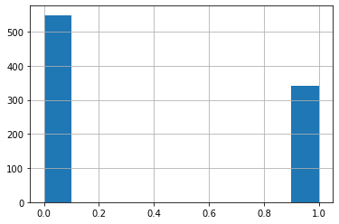

```python
my_hist = my_data_frame['Survived'].hist()
```

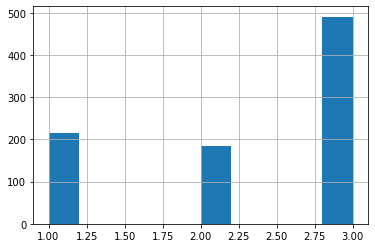

```python
my_hist = my_data_frame['Pclass'].hist()
```

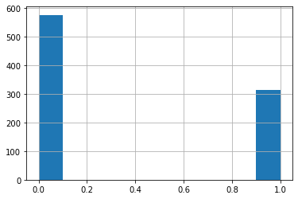

```python
my_hist = my_data_frame['Sex'].hist()
```

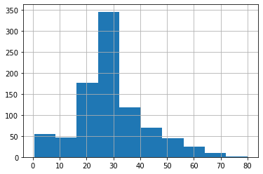

```python
my_hist = my_data_frame['Age'].hist()
```

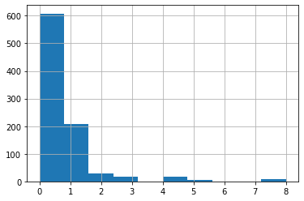

```python
my_hist = my_data_frame['SibSp'].hist()
```

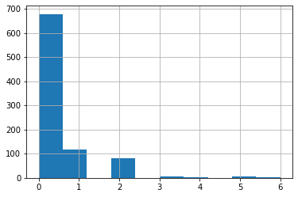

```python
my_hist = my_data_frame['Parch'].hist()
```

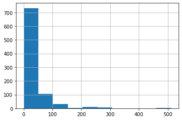

```python
my_hist = my_data_frame['Fare'].hist()
```

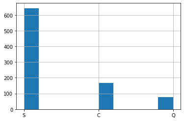

```python
my_hist = my_data_frame['Embarked'].hist()
```